# Анализ жд грузоперевозок.

Посмотрим на динамику количества вагонов на отдельном графике каждого направления по месяцам:

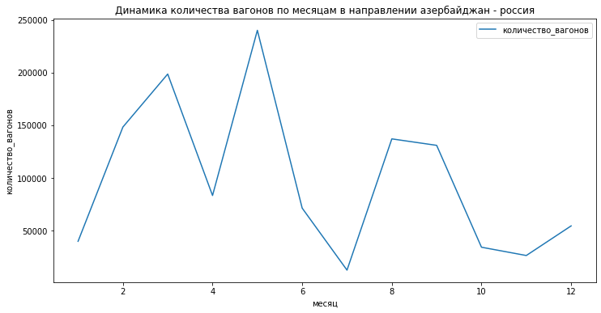

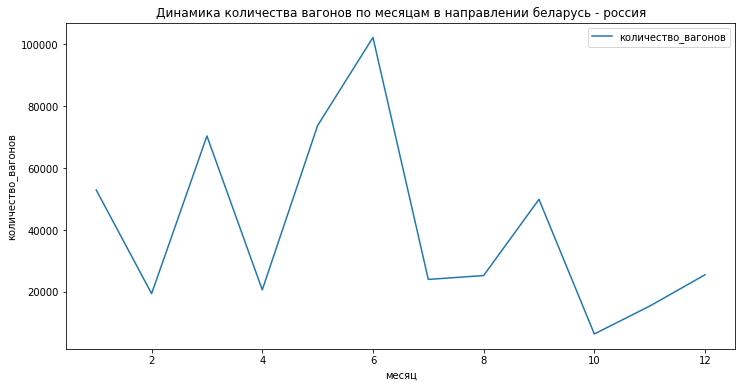

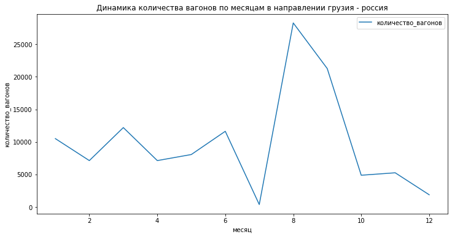

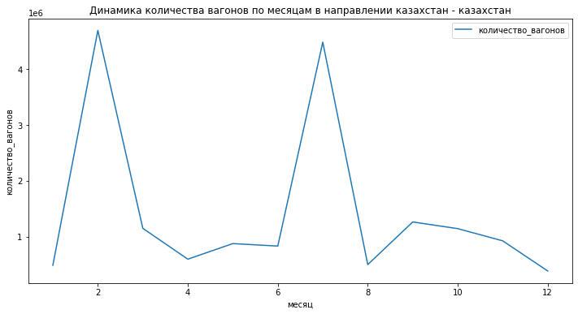

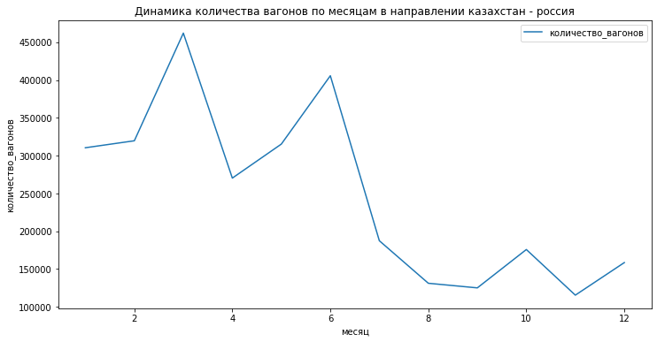

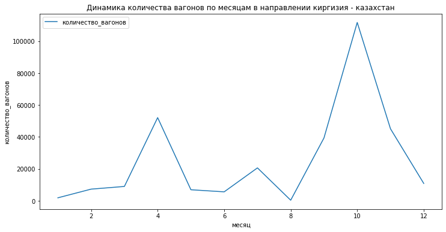

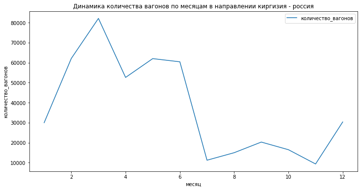

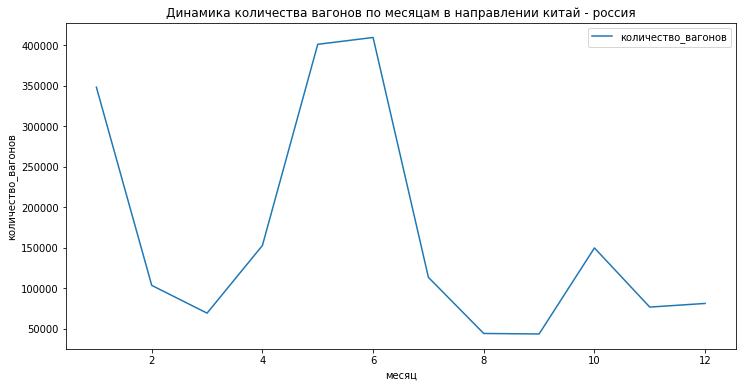

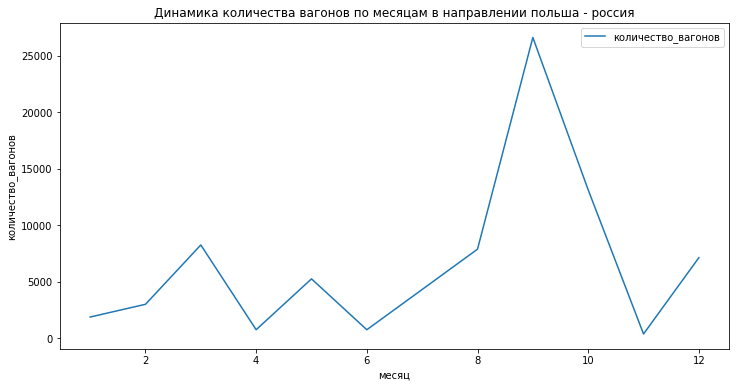

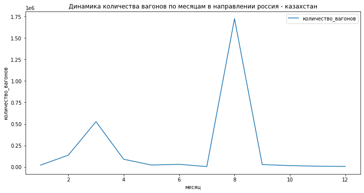

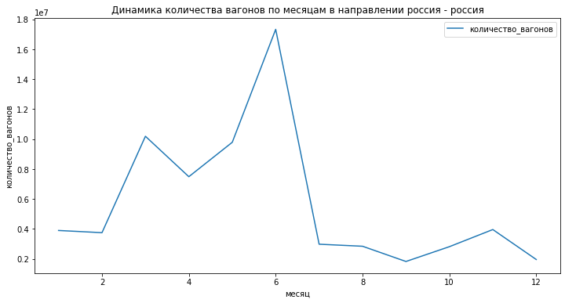

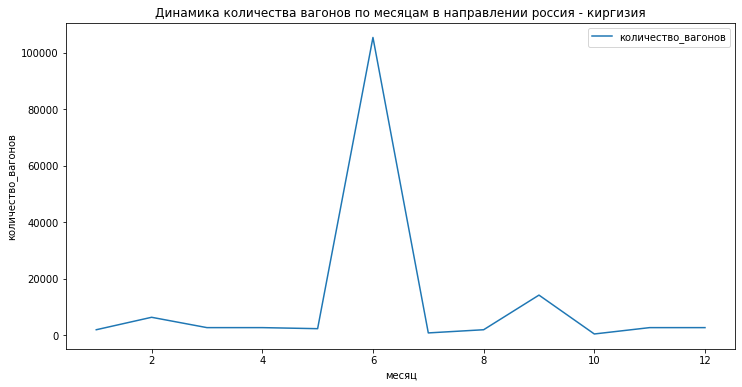

[14 more figures not shown]

```python
for direction in data['направление'].unique():
    min_num_month = len(data[data['направление'] == direction]['месяц'].unique())
    if min_num_month > 10:
        (data[(data['страна_прибытия'] != 'unknown') & (data['страна_отправления'] != 'unknown') & (data['направление'] == direction)]
         .groupby('месяц')
         .agg({'количество_вагонов': 'sum'})
         .reset_index()
         .plot(x='месяц', y='количество_вагонов', figsize=(12, 6))
        )
        plt.xlabel('месяц')
        plt.ylabel('количество_вагонов')
        plt.title(f'Динамика количества вагонов по месяцам в направлении {direction}')
        plt.show()
```

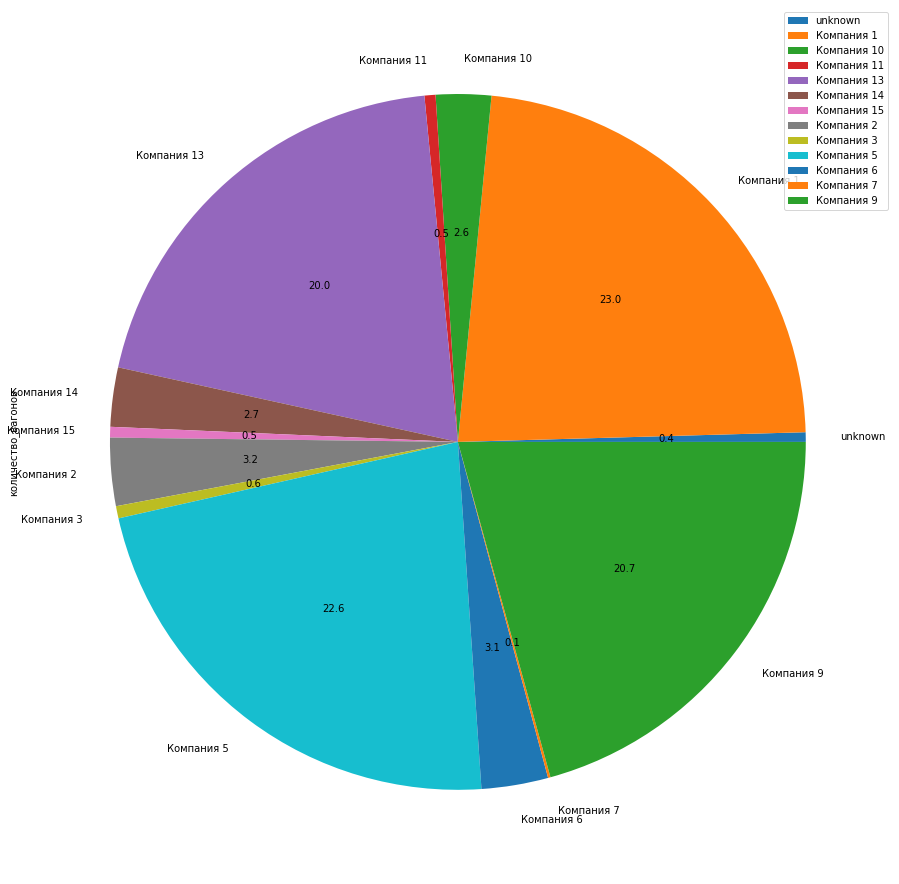

```python
(data.query('(месяц == 4 or месяц == 5 or месяц == 6) and страна_отправления == "россия" and год == 2020')
 .groupby('название_компаний')
 .agg({'количество_вагонов': 'sum'})
 .plot(kind='pie', y='количество_вагонов', figsize=(16, 16), autopct = '%.1f')
)
plt.show()
```

### Оценим отклонение от нормы в данных по суммарному количеству вагонов в месяц, независимо от типа вагонов в виде распределения Гаусса

```python
sum_of_wagons_months = data.groupby('месяц').agg({'количество_вагонов': 'sum'})
sum_of_wagons_months
```

| месяц | количество_вагонов |
| --- | --- |
| 1 | 7.733940e+06 |
| 2 | 1.299435e+07 |
| 3 | 1.543764e+07 |
| 4 | 1.064751e+07 |
| 5 | 1.336421e+07 |
| 6 | 2.178060e+07 |
| 7 | 1.078847e+07 |
| 8 | 8.465872e+06 |
| 9 | 4.792832e+06 |
| 10 | 5.982000e+06 |
| 11 | 6.621918e+06 |
| 12 | 3.782034e+06 |

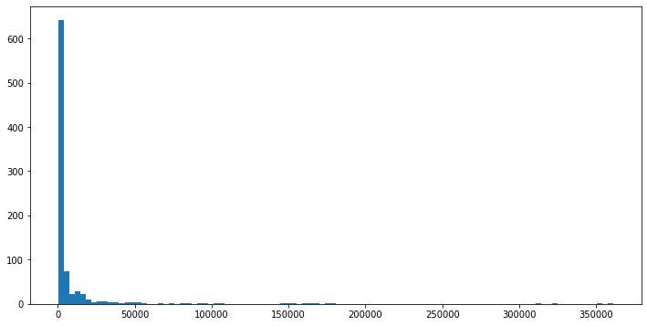

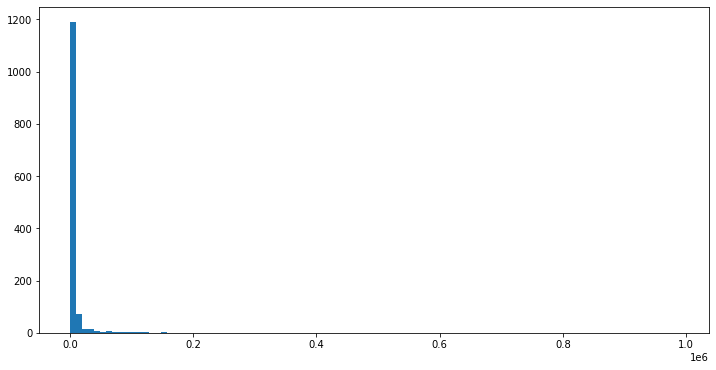

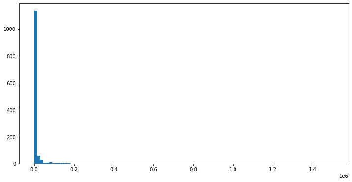

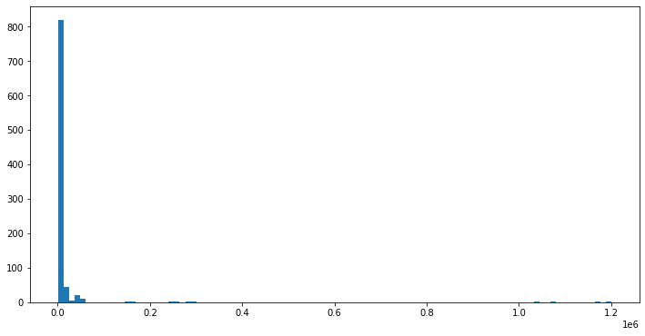

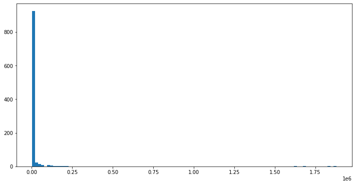

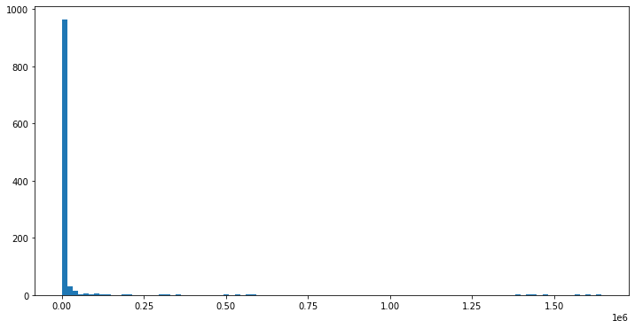

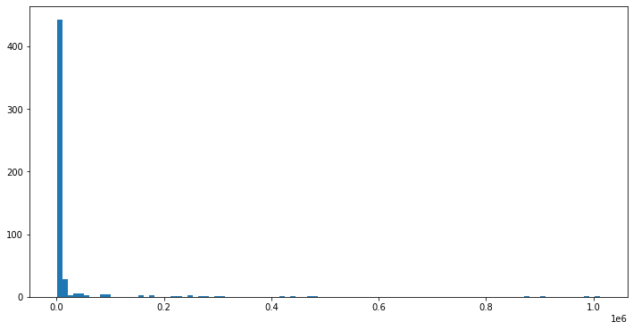

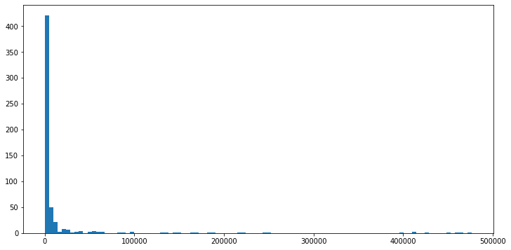

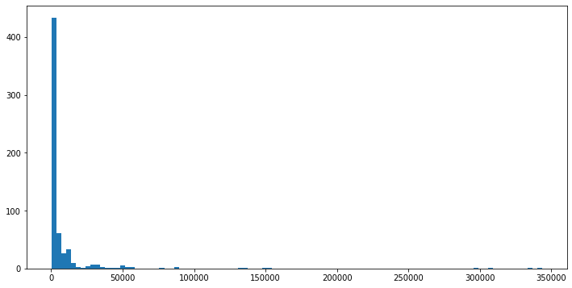

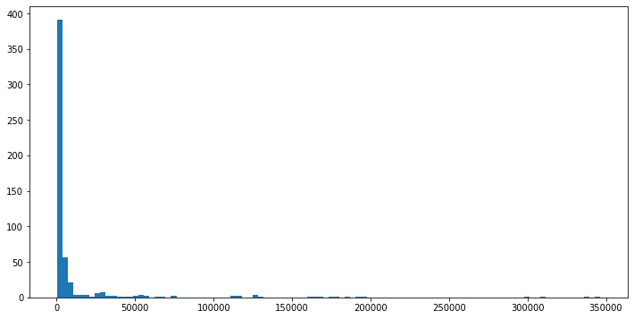

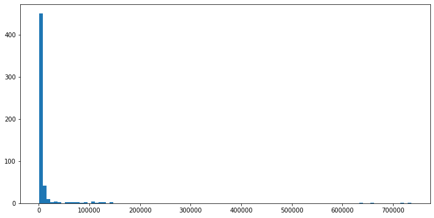

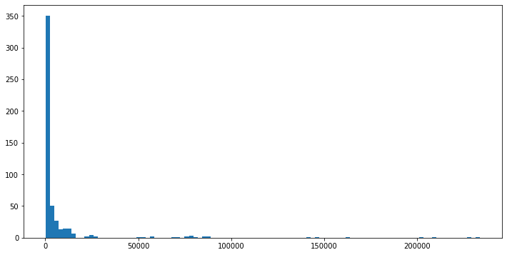

```python
for month in range(1, 13):
    tmp = data.query('месяц == @month')
    plt.figure(figsize=(12, 6))
    plt.hist('количество_вагонов', bins=100, data=tmp)
    plt.show()
```

Откинем выбросы по правилу трёмх сигм и снова посмотрим на гистограммы:

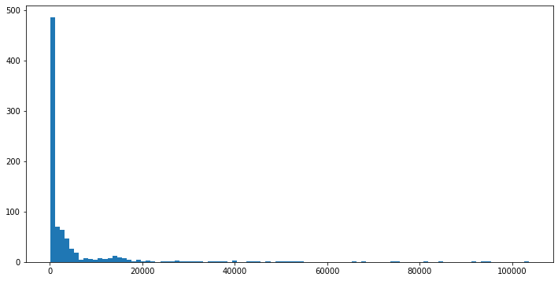

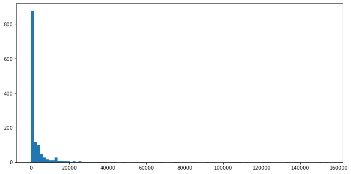

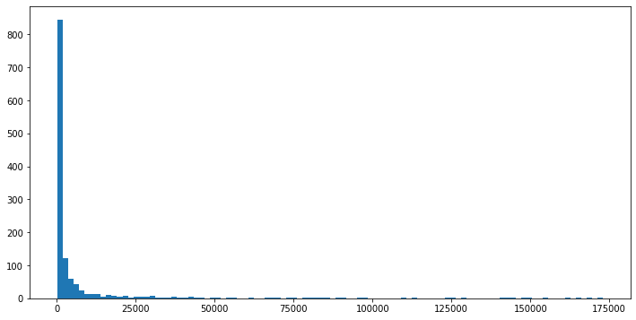

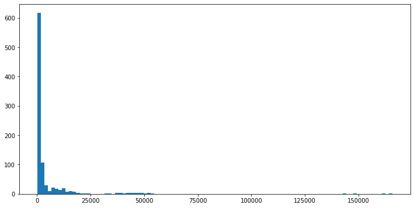

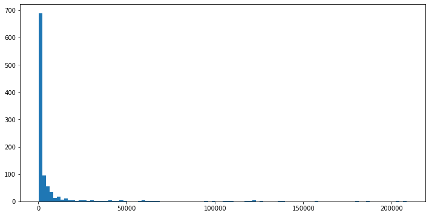

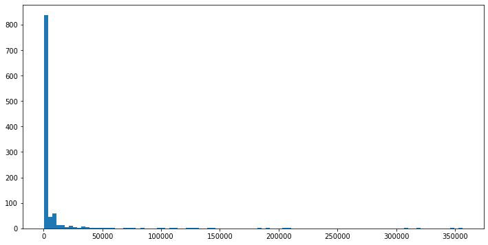

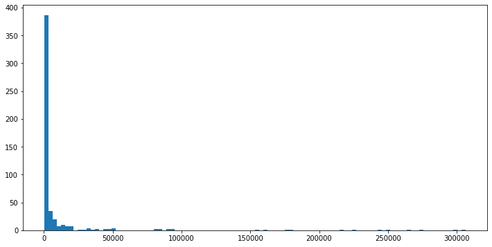

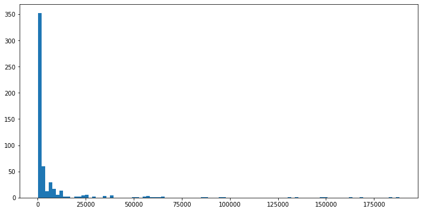

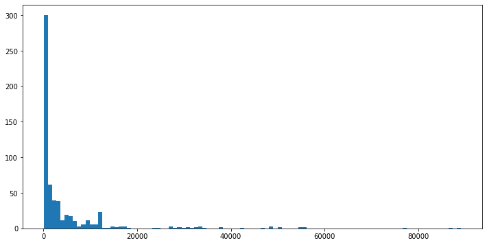

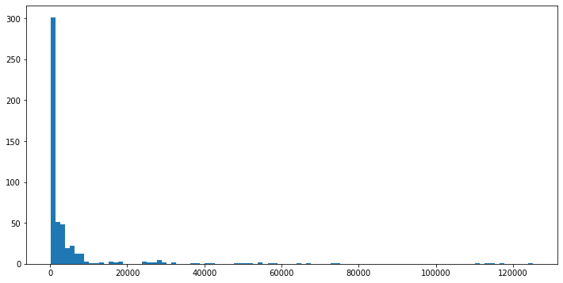

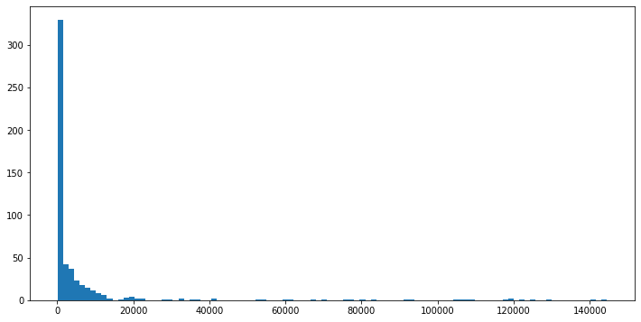

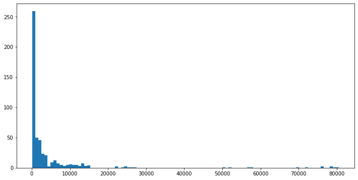

```python
for month in range(1, 13):
    tmp = data.query('месяц == @month')
    maximum = tmp['количество_вагонов'].mean() + (3 * np.std(tmp['количество_вагонов']))
    minimum = tmp['количество_вагонов'].mean() - (3 * np.std(tmp['количество_вагонов']))
    three_sigma = tmp.query('@minimum < количество_вагонов < @maximum')
    plt.figure(figsize=(12, 6))
    plt.hist('количество_вагонов', bins=100, data=three_sigma)
    plt.show()
```

На мой взгляд стоит откинуть хвосты побольше.

```python
data['количество_вагонов'].describe()
```

```
count    9.678000e+03
mean     1.264635e+04
std      8.126644e+04
min      8.700000e+01
25%      2.000000e+02
50%      7.200000e+02
75%      3.420000e+03
max      1.882100e+06
Name: количество_вагонов, dtype: float64
```

```python
data['количество_вагонов'].describe()[4]
```

```
200.0
```

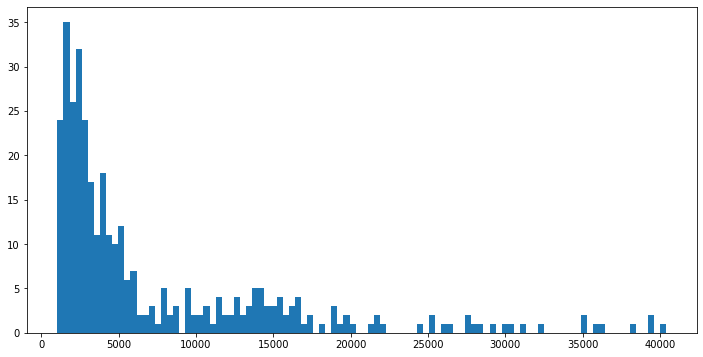

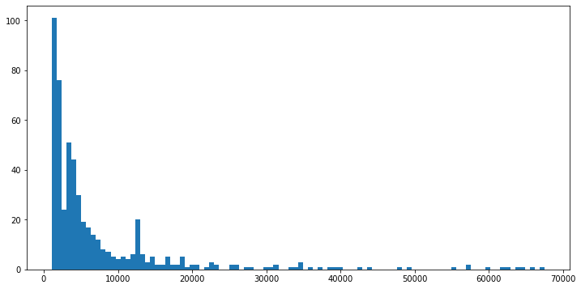

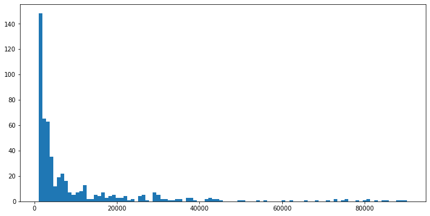

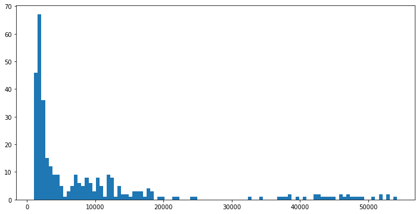

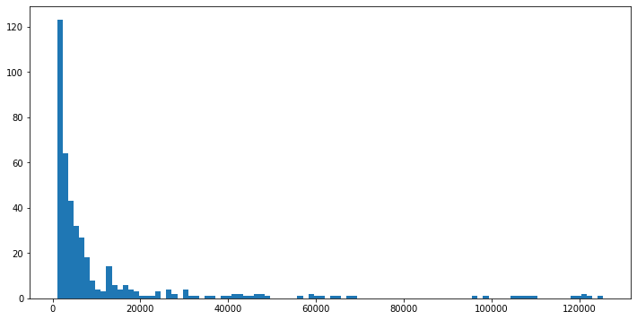

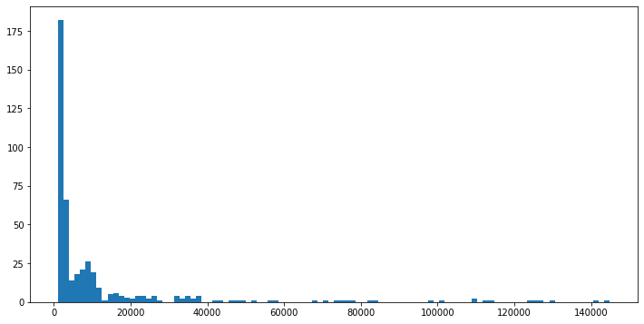

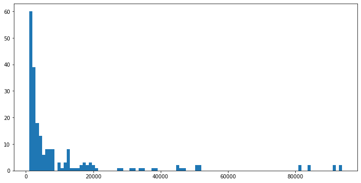

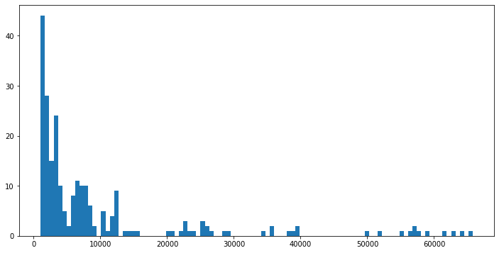

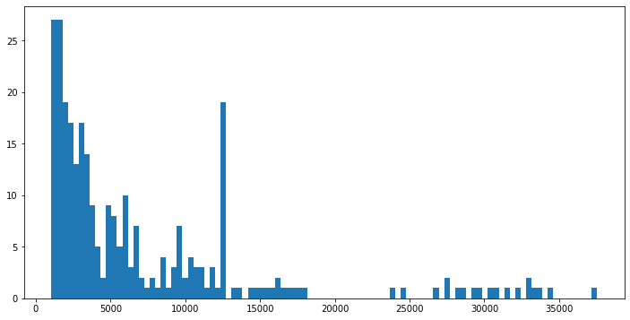

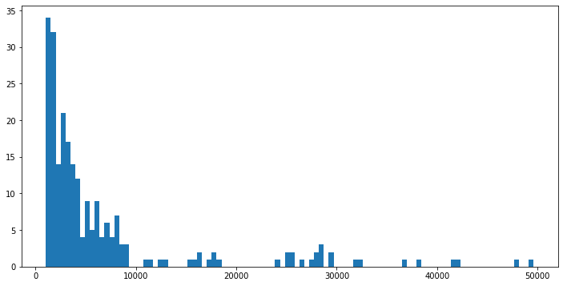

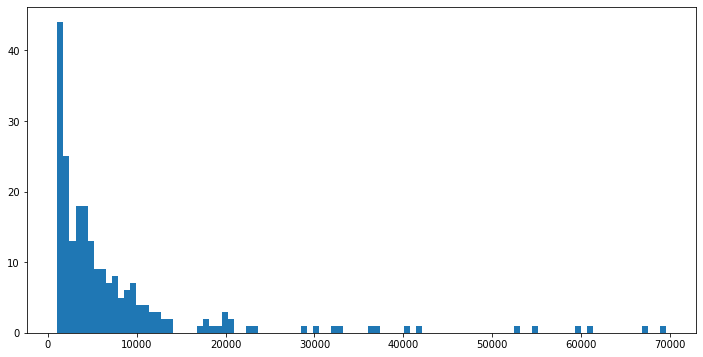

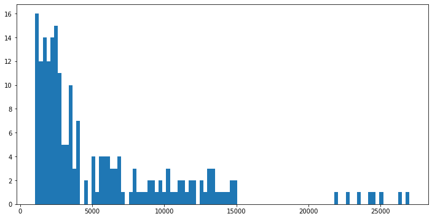

```python
for month in range(1, 13):
    tmp = data.query('месяц == @month')
    maximum = tmp['количество_вагонов'].mean() + (1 * np.std(tmp['количество_вагонов']))
    #minimum = tmp['количество_вагонов'].mean() - (1 * np.std(tmp['количество_вагонов']))
    #minimum = tmp['количество_вагонов'].describe()[4]
    three_sigma = tmp.query('1000 < количество_вагонов < @maximum')
    plt.figure(figsize=(12, 6))
    plt.hist('количество_вагонов', bins=100, data=three_sigma)
    plt.show()
```

Так их можно рассматривать.

Вид распределений похож на распределения Пуассона, а не нормальное распределение Гауса.

# Создадим таблицу по посчитанным ошибкам:

Ошибки:

Пропуски:  
Вагонов = 70  
Выручка = 15

Название компаний(2222) = 25

Год(2 019, 2О19, 2О19) = 20

Месяц(07.01.19**) = 72

Страна отправления(7777777) = 52 Страна отправления(По разному написаны страны и прочие страны) = 80

Тип вагона('Цестерны', 'Полумагоны', 'Крысые', 'Полубагоны') = 72

Страна прибытия(7777777) = 16  
Страна прибытия(По разному написаны страны и прочие страны) = 313

Вагонов ('в', 'й', 'у', 'цй', 'к', 'е', 'й', 'цу', 'кцук', 'цу', 'пе', 'кке', 'йц', 'йцу', 'йуйцу') = 15

```python
columns = ['Название ошибки', 'Название компаний', 'Год', 'Месяц', 'Страна отправления', 'Тип вагона', 'Страна прибытия', 'Вагонов', 'Выручка']
errors = [['Пропуски', 0, 0, 0, 0, 0, 0, 70, 15],
         ['int в string', 25, 0, 0, 52, 0, 16, 0, 0],
         ['Разное написание - один смысл и прочие страны', 0, 0, 0, 80, 0, 313, 0, 0],
         ['string в int', 0, 20, 0, 0, 0, 0, 0, 0],
         ['Предположительные сбои', 0, 0, 72, 0, 0, 0, 0, 0],
         ['Опечатки', 0, 0, 0, 0, 72, 0, 15, 0],
        ]
```

```python
errors_tabl = pd.DataFrame(data=errors, columns=columns)
errors_tabl
```

|  | Название ошибки | Название компаний | Год | Месяц | Страна отправления | Тип вагона | Страна прибытия | Вагонов | Выручка |
| --- | --- | --- | --- | --- | --- | --- | --- | --- | --- |
| 0 | Пропуски | 0 | 0 | 0 | 0 | 0 | 0 | 70 | 15 |
| 1 | int в string | 25 | 0 | 0 | 52 | 0 | 16 | 0 | 0 |
| 2 | Разное написание - один смысл и прочие страны | 0 | 0 | 0 | 80 | 0 | 313 | 0 | 0 |
| 3 | string в int | 0 | 20 | 0 | 0 | 0 | 0 | 0 | 0 |
| 4 | Предположительные сбои | 0 | 0 | 72 | 0 | 0 | 0 | 0 | 0 |
| 5 | Опечатки | 0 | 0 | 0 | 0 | 72 | 0 | 15 | 0 |